# Belajar R Visualisasi dengan Library ggplot2

Eko Teguh Widodo

2024-08-24

## Pendahuluan

Penyajian data merupakan bentuk pengemasan suatu data secara visual sedemikian sehingga data lebih mudah dipahami. Penyajian data bisa dilakukan dalam bentuk tabel, diagram, maupun grafik.

Penyajian data yang baik:

- Menarik perhatian pembaca.
- Menyajikan informasi secara sederhana, jelas, dan akurat.
- Tidak misleading.
- Memfasilitasi perbandingan.
- Mengilustrasikan pesan, tema atau jalan cerita dalam teks terkait.

`ggplot2` adalah salah satu paket visualisasi data paling populer di R karena fleksibilitas dan kemampuannya untuk membuat grafik yang sangat menarik dan informatif. Paket ini didasarkan pada konsep **Grammar of Graphics** yang memungkinkan kita untuk membangun plot dengan menambahkan layer secara bertahap.

**Struktur `ggplot2`**

- `ggplot(data, aes())`: Fungsi dasar untuk memulai plot. Anda menentukan dataset dan mapping estetika (aes) seperti sumbu X dan Y.
- `geom_*`: Fungsi untuk menambahkan layer tipe plot, seperti `geom_point()` untuk scatter plot, `geom_bar()` untuk bar plot, `geom_line()` untuk line plot, dan sebagainya.
- `labs()`, `theme()`, `scale_*`: Fungsi tambahan untuk menyesuaikan label, tema, dan skala pada plot.

### Contoh 1: Scatter plot sederhana

Silahkan buka pembelajaran saya [yang ini](https://rpubs.com/ekoteguh/belajar-r-visualisasi-dengan-plot) dimana di bagian akhir, ada implementasi dataset yang digunakan, yaitu data keuangan.

```r
# Membuat data yang lebih besar dengan memperbanyak jumlah satker, kegiatan, dan akun
set.seed(123)  # Untuk menghasilkan data acak yang konsisten

# Contoh data
data_keuangan <- data.frame(
  nama_satker = rep(paste("Satker", LETTERS[1:10]), each = 10),
  nama_kegiatan = rep(paste("Kegiatan", 1:10), times = 10),
  nama_akun = rep(paste("Akun", 1:5), times = 20),
  target = sample(100:500, 100, replace = TRUE)
)

data_keuangan$realisasi = data_keuangan$target - sample(-50:50, 100, replace = TRUE)
data_keuangan$persentase_realisasi = (data_keuangan$realisasi / data_keuangan$target) * 100

head(data_keuangan)
```

```
##   nama_satker nama_kegiatan nama_akun target realisasi persentase_realisasi
## 1    Satker A    Kegiatan 1    Akun 1    278       321            115.46763
## 2    Satker A    Kegiatan 2    Akun 2    113       113            100.00000
## 3    Satker A    Kegiatan 3    Akun 3    294       271             92.17687
## 4    Satker A    Kegiatan 4    Akun 4    405       406            100.24691
## 5    Satker A    Kegiatan 5    Akun 5    217       170             78.34101
## 6    Satker A    Kegiatan 6    Akun 1    398       375             94.22111
```

```r
# Menghitung data tambahan yang diperlukan
agg_data <- aggregate(cbind(target, realisasi) ~ nama_satker, data = data_keuangan, sum)
agg_data_kegiatan <- aggregate(realisasi ~ nama_kegiatan, data = data_keuangan, sum)  # Agregasi per kegiatan
agg_data$selisih <- agg_data$target - agg_data$realisasi
```

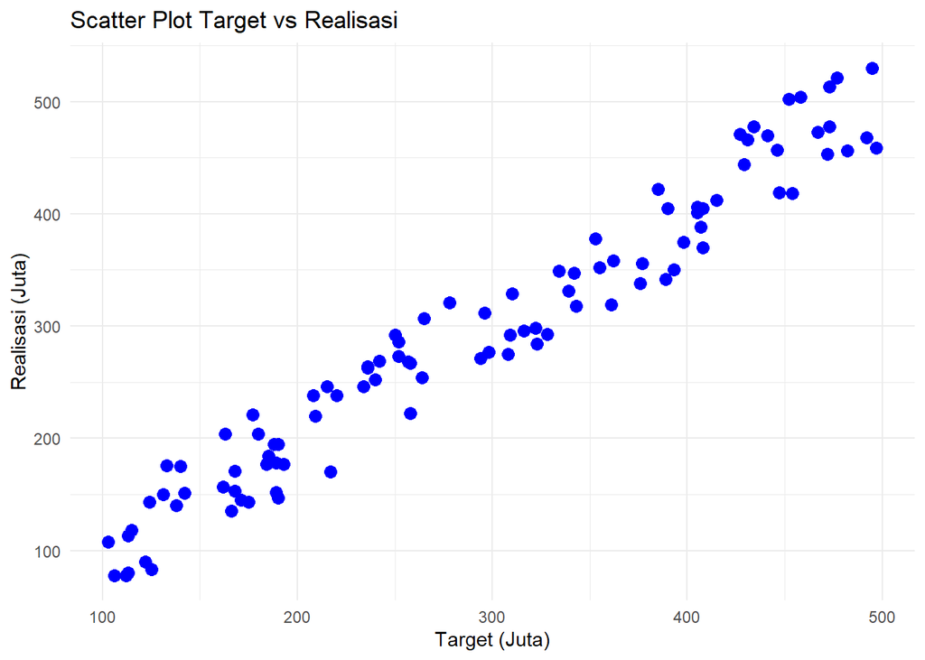

```r
library(ggplot2)

# Membuat scatter plot dengan ggplot2
scatter_plot = ggplot(data_keuangan, aes(x = target, y = realisasi)) +
  geom_point(color = "blue", size = 3) +
  labs(title = "Scatter Plot Target vs Realisasi",
       x = "Target (Juta)",
       y = "Realisasi (Juta)") +
  theme_minimal()

scatter_plot
```

### Contoh 2: Bar Plot untuk Perbandingan

Sekarang kita akan membuat bar plot yang menampilkan total realisasi per kegiatan.

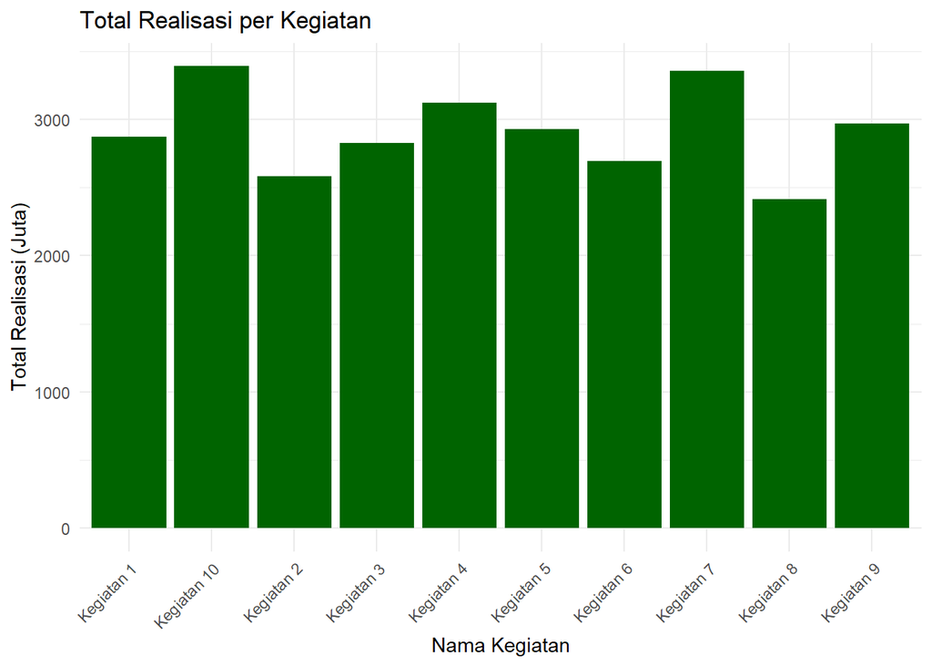

```r
# Membuat bar plot dengan ggplot2
bar_plot = ggplot(agg_data_kegiatan, aes(x = nama_kegiatan, y = realisasi)) +
  geom_bar(stat = "identity", fill = "darkgreen") +
  labs(title = "Total Realisasi per Kegiatan",
       x = "Nama Kegiatan",
       y = "Total Realisasi (Juta)") +
  theme_minimal() +
  theme(axis.text.x = element_text(angle = 45, hjust = 1))

bar_plot
```

### Contoh 3: Boxplot untuk Distribusi

Mari kita buat boxplot untuk melihat distribusi realisasi per akun.

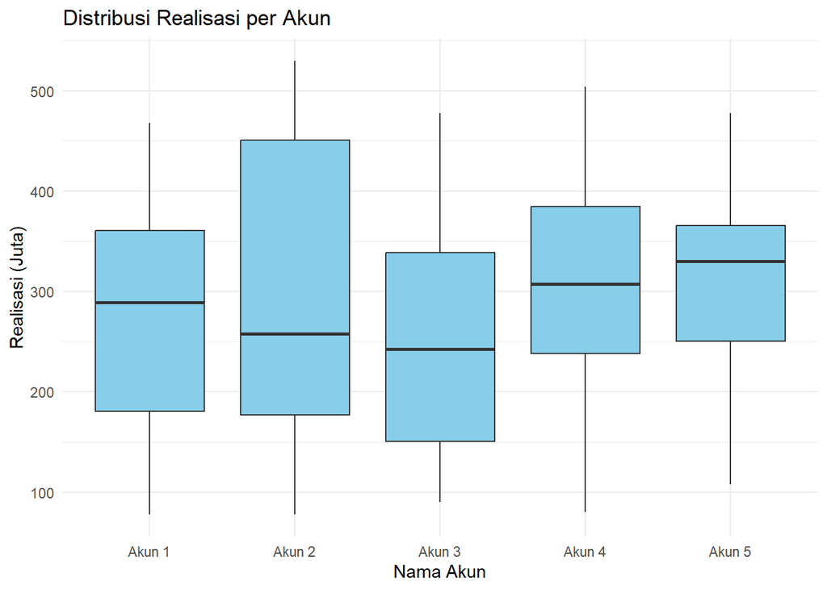

```r
# Membuat boxplot dengan ggplot2
box_plot = ggplot(data_keuangan, aes(x = nama_akun, y = realisasi)) +
  geom_boxplot(fill = "skyblue") +
  labs(title = "Distribusi Realisasi per Akun",
       x = "Nama Akun",
       y = "Realisasi (Juta)") +
  theme_minimal()

box_plot
```

### Contoh 4: Bar Plot Horizontal

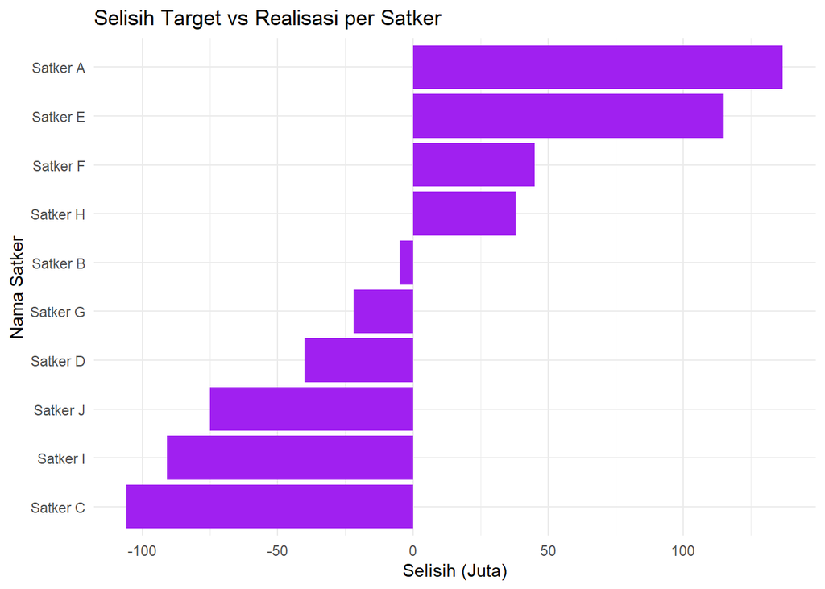

```r
# Membuat bar plot horizontal dengan ggplot2
bar_plot_horiz = ggplot(agg_data, aes(x = selisih, y = reorder(nama_satker, selisih))) +
  geom_bar(stat = "identity", fill = "purple") +
  labs(title = "Selisih Target vs Realisasi per Satker",
       x = "Selisih (Juta)",
       y = "Nama Satker") +
  theme_minimal()

bar_plot_horiz
```

Seperti pada latihan sebelumnya, bahwa dengan `par()` atau `layout()` kita bisa menggabungkan keempat grafik tersebut ke dalam satu tempat. Pada sesi kali ini kita bisa memanfaatkan library lain, seperti `patchwork` yang memungkinkan Anda untuk menggabungkan beberapa plot ggplot2 dengan mudah. Cukup gunakan operator + untuk menggabungkan plot.

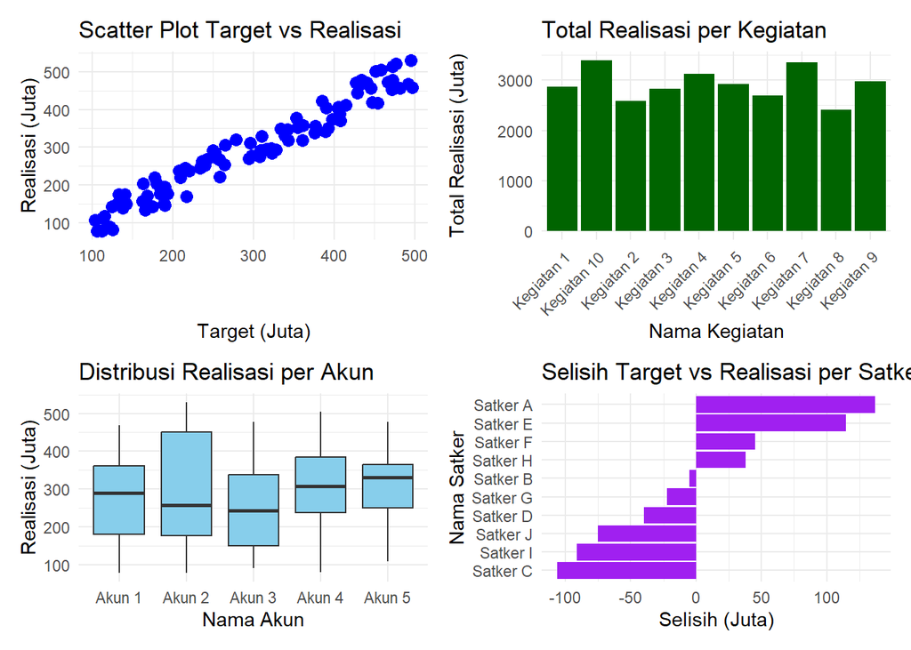

```r
library(patchwork)

# Menggabungkan beberapa plot
scatter_plot + bar_plot + box_plot + bar_plot_horiz
```

Jika dilihat dan dibandingkan dengan penggunaan `plot()` sebelumnya, tampilannya lebih tertata rapih untuk penggunaan `ggplot2`.

## Fitur Lanjutan `ggplot2`

### 1. Faceting: Membuat Subplots Berdasarkan Kategori

Faceting memungkinkan untuk memecah data menjadi subset dan membuat plot terpisah untuk setiap subset dalam satu tampilan. Ini sangat berguna untuk membandingkan beberapa kategori. Dengan faceting, dapat membantu melihat pola atau hubungan dalam data yang berbeda-beda untuk setiap kategori.

Contoh: Memecah scatter plot berdasarkan nama_akun menggunakan `facet_wrap()`.

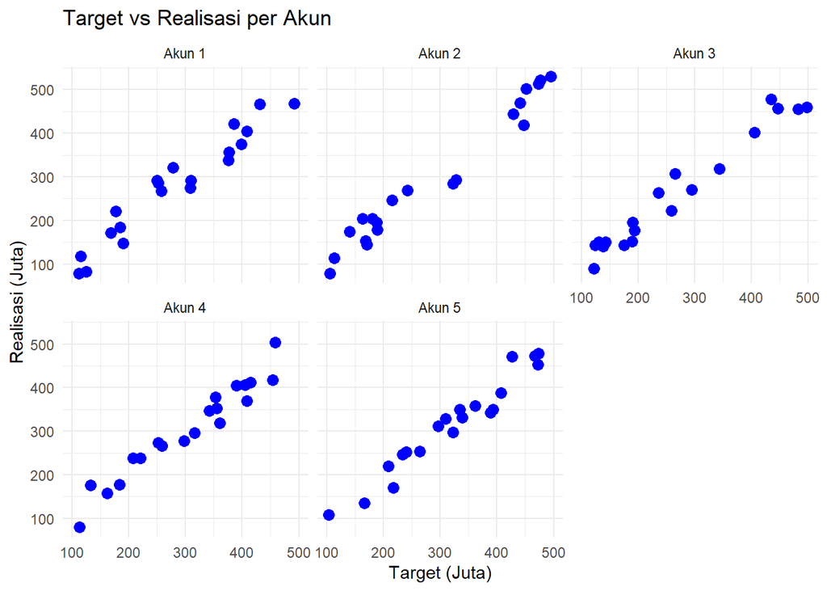

```r
faceting_plot <- ggplot(data_keuangan, aes(x = target, y = realisasi)) +
  geom_point(color = "blue", size = 3) +
  labs(title = "Target vs Realisasi per Akun",
       x = "Target (Juta)",
       y = "Realisasi (Juta)") +
  facet_wrap(~nama_akun) +
  theme_minimal()

faceting_plot
```

Selain `facet_wrap`, kita dapat menggunakan `facet_grid` untuk memfasilitasi pemecahan plot berdasarkan dua variabel (satu di sumbu X dan satu di sumbu Y).

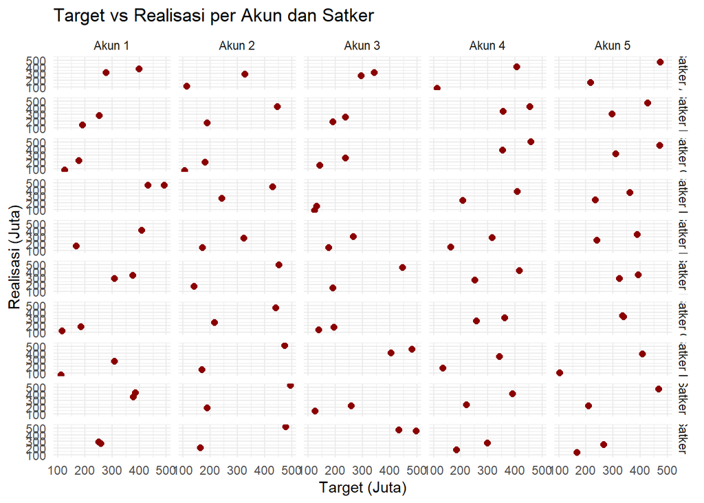

```r
facetgrid_plot <- ggplot(data_keuangan, aes(x = target, y = realisasi)) +
  geom_point(color = "darkred", size = 2) +
  labs(title = "Target vs Realisasi per Akun dan Satker",
       x = "Target (Juta)",
       y = "Realisasi (Juta)") +
  facet_grid(nama_satker ~ nama_akun) +
  theme_minimal()

facetgrid_plot
```

### 2. Custom Themes: Mengkustomisasi Tampilan Plot

Kita dapat membuat tampilan plot lebih konsisten dengan tema khusus yang disesuaikan dengan gaya atau kebutuhan tertentu. `ggplot2` memungkinkan Anda untuk membuat custom themes.

Contoh: Menggunakan `theme_classic()` dan menyesuaikan beberapa elemen. `theme_classic()` merupakan tema klasik yang sederhana dan bersih.

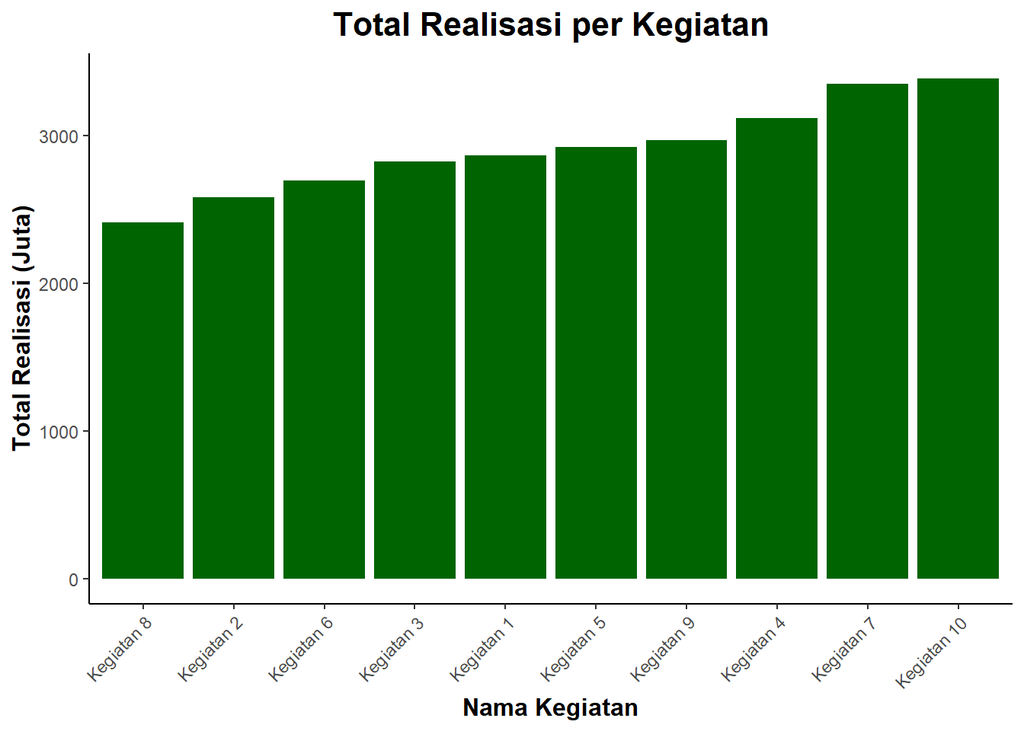

```r
custom_plot <- ggplot(agg_data_kegiatan, aes(x = reorder(nama_kegiatan, realisasi), y = realisasi)) +
  geom_bar(stat = "identity", fill = "darkgreen") +
  labs(title = "Total Realisasi per Kegiatan",
       x = "Nama Kegiatan",
       y = "Total Realisasi (Juta)") +
  theme_classic() +
  theme(axis.text.x = element_text(angle = 45, hjust = 1),
        plot.title = element_text(hjust = 0.5, size = 16, face = "bold"),
        axis.title.x = element_text(size = 12, face = "bold"),
        axis.title.y = element_text(size = 12, face = "bold"))

custom_plot
```

Dengan `theme()`, kita bisa menyesuaikan hampir setiap aspek dari plot `ggplot2`, termasuk elemen-elemen yang mungkin jarang digunakan.

Contoh: Menyesuaikan elemen tema secara mendetail.

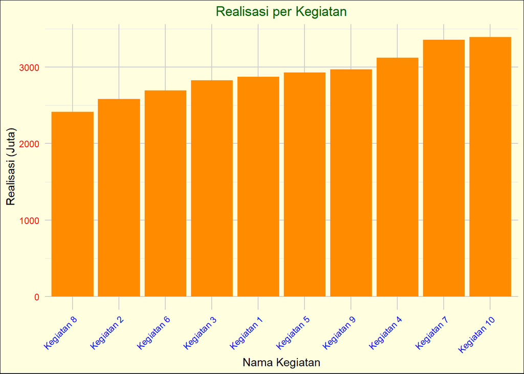

```r
theme_plot <- ggplot(agg_data_kegiatan, aes(x = reorder(nama_kegiatan, realisasi), y = realisasi)) +
  geom_bar(stat = "identity", fill = "darkorange") +
  labs(title = "Realisasi per Kegiatan",
       x = "Nama Kegiatan",
       y = "Realisasi (Juta)") +
  theme_minimal() +
  theme(plot.background = element_rect(fill = "lightyellow"),
        panel.grid.major = element_line(color = "gray80"),
        panel.grid.minor = element_line(color = "gray90"),
        axis.text.x = element_text(color = "blue", angle = 45, hjust = 1),
        axis.text.y = element_text(color = "red"),
        plot.title = element_text(hjust = 0.5, color = "darkgreen"))

theme_plot
```

### 3. Color Scales: Mengatur Warna Berdasarkan Data

`ggplot2` memungkinkan kita untuk mengubah warna pada plot berdasarkan data, baik menggunakan skala warna kontinu maupun diskret. Warna dapat membantu untuk memvisualisasikan intensitas atau ukuran nilai dengan lebih efektif.

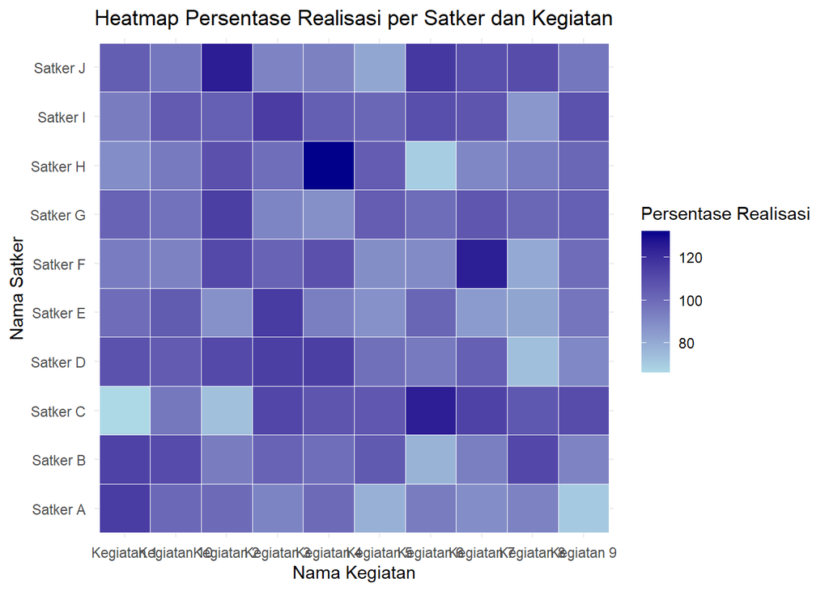

```r
color_plot <- ggplot(data_keuangan, aes(x = nama_kegiatan, y = nama_satker, fill = persentase_realisasi)) +
  geom_tile(color = "white") +
  scale_fill_gradient(low = "lightblue", high = "darkblue") +
  labs(title = "Heatmap Persentase Realisasi per Satker dan Kegiatan",
       x = "Nama Kegiatan",
       y = "Nama Satker",
       fill = "Persentase Realisasi") +
  theme_minimal()

color_plot
```

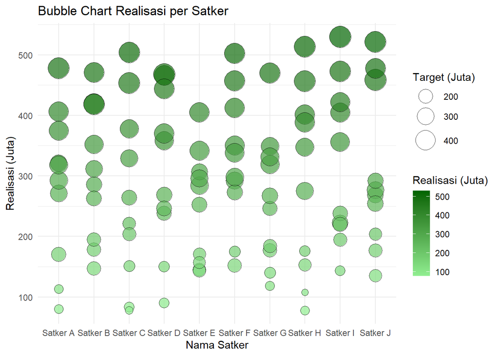

```r
bubble_plot <- ggplot(data_keuangan, aes(x = nama_satker, y = realisasi, size = target, fill = realisasi)) +
  geom_point(shape = 21, color = "black", alpha = 0.7) +
  scale_size(range = c(3, 10)) +
  scale_fill_gradient(low = "lightgreen", high = "darkgreen") +
  labs(title = "Bubble Chart Realisasi per Satker",
       x = "Nama Satker",
       y = "Realisasi (Juta)",
       size = "Target (Juta)",
       fill = "Realisasi (Juta)") +
  theme_minimal()

bubble_plot
```

### 4. Annotations: Menambahkan Teks dan Garis pada Plot

Annotations sangat berguna untuk menyoroti informasi penting langsung di dalam plot, seperti menambahkan teks atau garis referensi.

Contoh: Menambahkan garis referensi dan anotasi teks pada scatter plot.

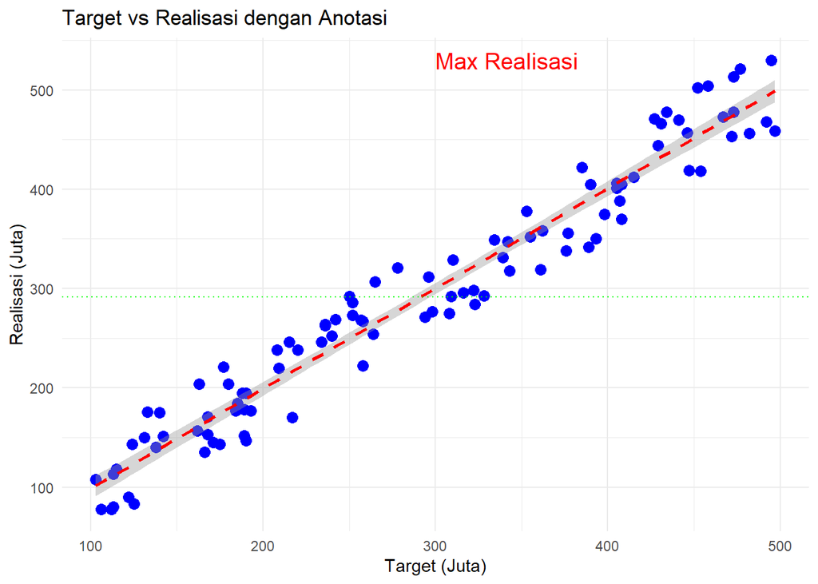

```r
annotation_plot <- ggplot(data_keuangan, aes(x = target, y = realisasi)) +
  geom_point(color = "blue", size = 3) +
  geom_smooth(method = "lm", color = "red", linetype = "dashed") +  # Menambahkan garis regresi
  geom_hline(yintercept = mean(data_keuangan$realisasi), color = "green", linetype = "dotted") +  # Garis referensi
  annotate("text", x = 300, y = max(data_keuangan$realisasi), label = "Max Realisasi", color = "red", size = 5, hjust = 0) +  # Anotasi teks
  labs(title = "Target vs Realisasi dengan Anotasi",
       x = "Target (Juta)",
       y = "Realisasi (Juta)") +
  theme_minimal()

annotation_plot
```

`geom_smooth` adalah cara untuk menambahkan garis tren atau fit model pada data, dengan opsi untuk menampilkan interval kepercayaan.

Contoh: Menambahkan garis regresi dengan interval kepercayaan pada scatter plot.

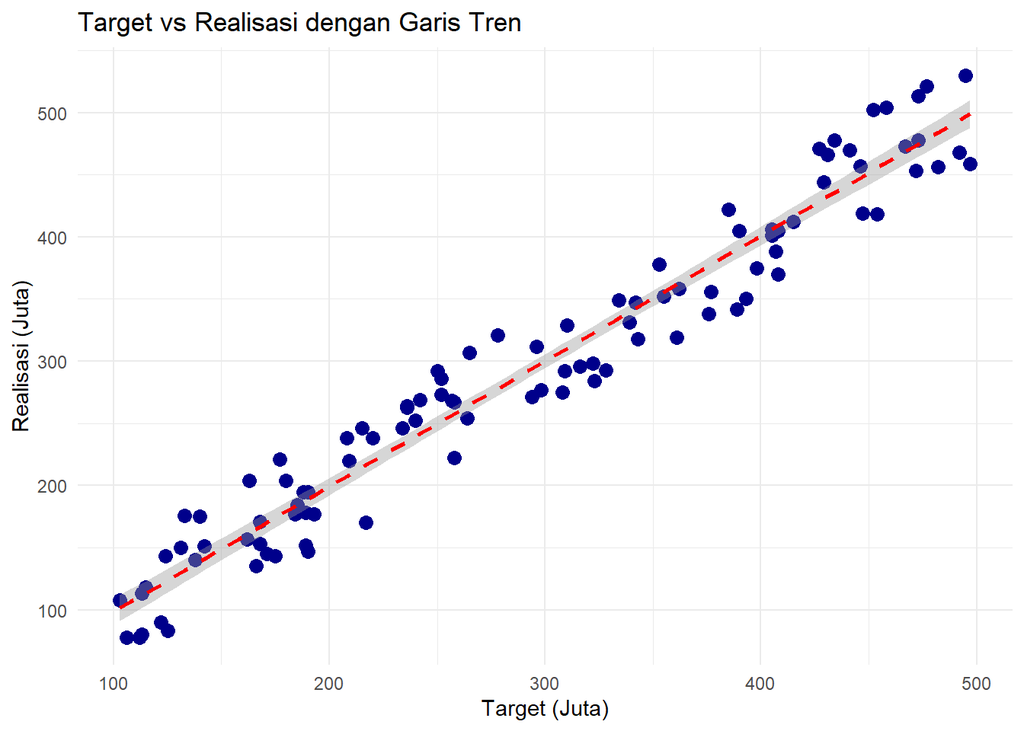

```r
smooth_plot <- ggplot(data_keuangan, aes(x = target, y = realisasi)) +
  geom_point(color = "darkblue", size = 3) +
  geom_smooth(method = "lm", se = TRUE, color = "red", linetype = "dashed") +  # Garis tren dengan interval kepercayaan
  labs(title = "Target vs Realisasi dengan Garis Tren",
       x = "Target (Juta)",
       y = "Realisasi (Juta)") +
  theme_minimal()

smooth_plot
```

### 5. Plot Kombinasi dengan `patchwork` or `cowplot`

Untuk menyusun beberapa plot dalam satu tampilan, `patchwork` atau `cowplot` adalah paket yang sangat berguna.

Contoh: Menggabungkan beberapa plot dengan `patchwork`.

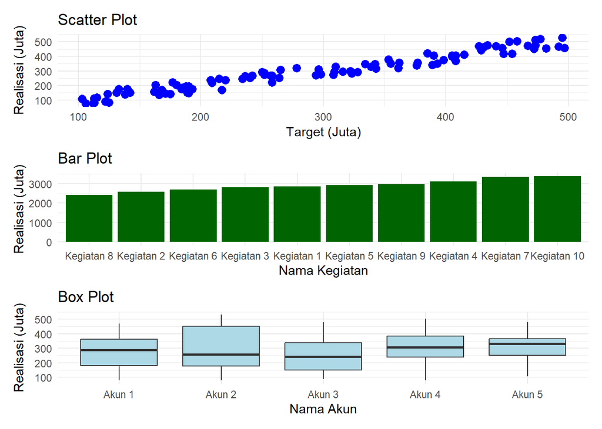

```r
library(patchwork)

scatter_plot <- ggplot(data_keuangan, aes(x = target, y = realisasi)) +
  geom_point(color = "blue", size = 3) +
  labs(title = "Scatter Plot",
       x = "Target (Juta)",
       y = "Realisasi (Juta)") +
  theme_minimal()

bar_plot <- ggplot(agg_data_kegiatan, aes(x = reorder(nama_kegiatan, realisasi), y = realisasi)) +
  geom_bar(stat = "identity", fill = "darkgreen") +
  labs(title = "Bar Plot",
       x = "Nama Kegiatan",
       y = "Realisasi (Juta)") +
  theme_minimal()

box_plot <- ggplot(data_keuangan, aes(x = nama_akun, y = realisasi)) +
  geom_boxplot(fill = "lightblue") +
  labs(title = "Box Plot",
       x = "Nama Akun",
       y = "Realisasi (Juta)") +
  theme_minimal()

# Menggabungkan plot dengan patchwork
combined_plot <- scatter_plot + bar_plot + box_plot + plot_layout(ncol = 1)
combined_plot
```

### 6. Penggunaan `coord_flip` untuk Membalik Sumbu X dan Y

Contoh: Membalik plot bar horizontal.

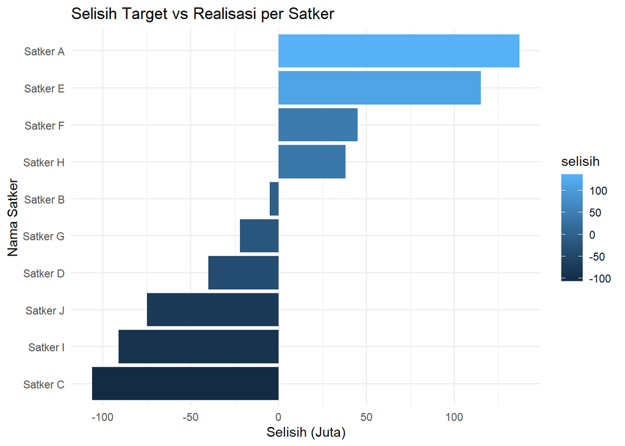

```r
flip_plot <- ggplot(agg_data, aes(x = reorder(nama_satker, selisih), y = selisih, fill = selisih)) +
  geom_bar(stat = "identity") +
  labs(title = "Selisih Target vs Realisasi per Satker",
       x = "Nama Satker",
       y = "Selisih (Juta)") +
  coord_flip() +  # Membalik sumbu X dan Y
  theme_minimal()

flip_plot
```

### 7. Menggunakan `geom_text` untuk Menambahkan Label pada Plot

Kita bisa menambahkan label teks pada titik data untuk memberikan informasi tambahan.

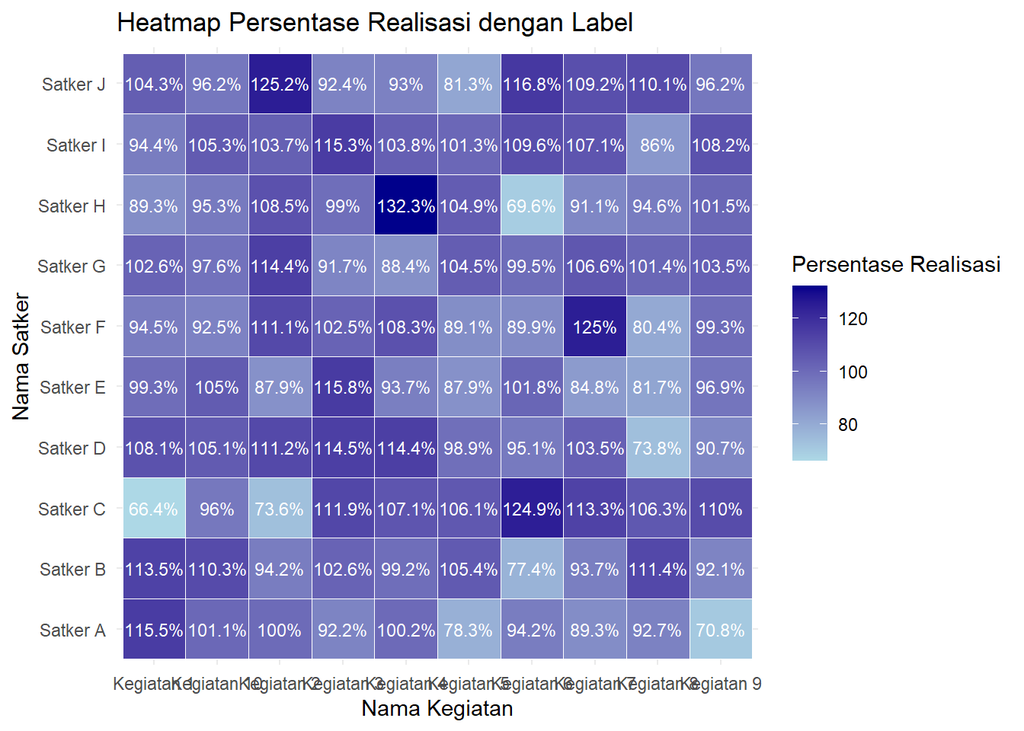

```r
label_plot <- # Membuat heatmap dengan label
ggplot(data_keuangan, aes(x = nama_kegiatan, y = nama_satker, fill = persentase_realisasi)) +
  geom_tile(color = "white") +
  geom_text(aes(label = paste0(round(persentase_realisasi, 1), "%")), color = "white", size = 3) +  # Menambahkan persentase realisasi
  scale_fill_gradient(low = "lightblue", high = "darkblue") +
  labs(title = "Heatmap Persentase Realisasi dengan Label",
       x = "Nama Kegiatan",
       y = "Nama Satker",
       fill = "Persentase Realisasi") +
  theme_minimal()

label_plot
```

### 8. Kustomisasi Legends

Kita bisa mengontrol bagaimana legenda ditampilkan, termasuk posisinya, judulnya, dan elemen lain yang terkait.

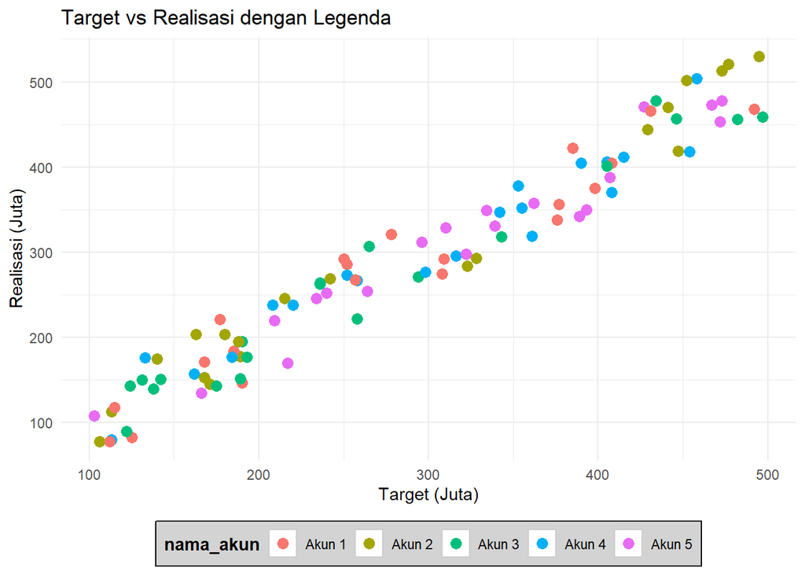

```r
legend_plot <- ggplot(data_keuangan, aes(x = target, y = realisasi, color = nama_akun)) +
  geom_point(size = 3) +
  labs(title = "Target vs Realisasi dengan Legenda",
       x = "Target (Juta)",
       y = "Realisasi (Juta)") +
  theme_minimal() +
  theme(legend.position = "bottom",  # Posisi legenda di bawah plot
        legend.title = element_text(face = "bold"),
        legend.background = element_rect(fill = "lightgray", color = "black", size = 0.5),
        legend.key = element_rect(fill = "white", color = "gray80"))
legend_plot
```

### 9. Menggunakan `geom_violin` untuk Menampilkan Distribusi Data

`geom_violin()` adalah alternatif visualisasi yang menggabungkan boxplot dan density plot, memberikan gambaran distribusi yang lebih rinci.

Contoh: Menggunakan `geom_violin` untuk distribusi realisasi per akun.

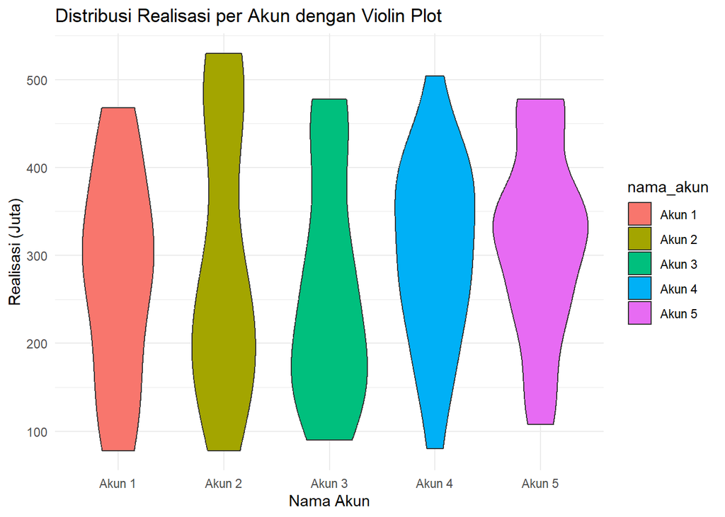

```r
violin_plot <- ggplot(data_keuangan, aes(x = nama_akun, y = realisasi, fill = nama_akun)) +
  geom_violin() +
  labs(title = "Distribusi Realisasi per Akun dengan Violin Plot",
       x = "Nama Akun",
       y = "Realisasi (Juta)") +
  theme_minimal()

violin_plot
```

### 10. Menggunakan Palet Warna `RColorBrewer`

Kita bisa menggunakan palet warna dari RColorBrewer untuk membuat grafik lebih menarik secara visual, terutama ketika kita bekerja dengan banyak kategori.

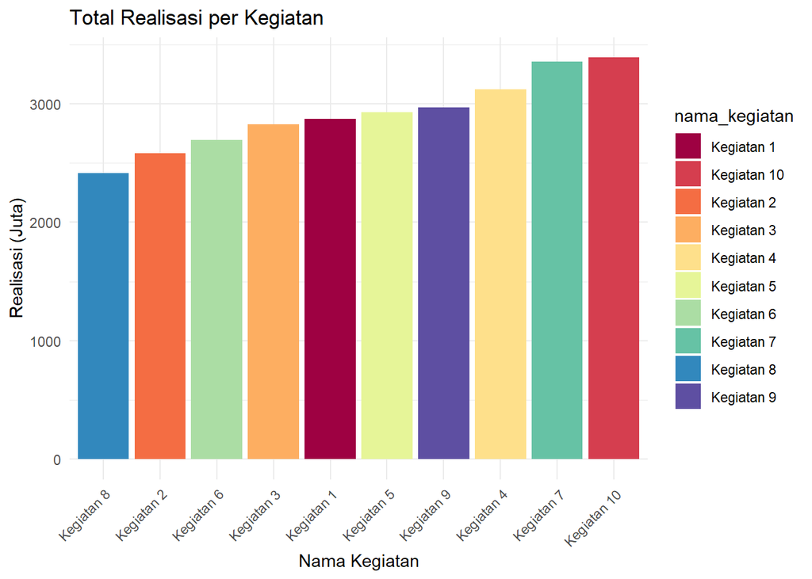

```r
library(RColorBrewer)

palet_plot <- ggplot(agg_data_kegiatan, aes(x = reorder(nama_kegiatan, realisasi), y = realisasi, fill = nama_kegiatan)) +
  geom_bar(stat = "identity") +
  scale_fill_brewer(palette = "Spectral") +  # Menggunakan palet warna dari RColorBrewer
  labs(title = "Total Realisasi per Kegiatan",
       x = "Nama Kegiatan",
       y = "Realisasi (Juta)") +
  theme_minimal() +
  theme(axis.text.x = element_text(angle = 45, hjust = 1))

palet_plot
```

### 11. Sankey Diagram

Sankey diagram adalah jenis diagram alir yang digunakan untuk menggambarkan bagaimana sesuatu (seperti uang, energi, atau sumber daya lainnya) mengalir dari satu titik ke titik lainnya. Ini sangat berguna untuk menunjukkan aliran dalam sistem yang kompleks dan bisa menjadi cara yang sangat efektif untuk memvisualisasikan data keuangan atau aliran lainnya.

Meskipun `ggplot2` tidak mendukung Sankey diagram secara langsung, ada beberapa paket di R yang memungkinkan Anda untuk membuat Sankey diagram dengan mudah. Salah satu paket yang populer untuk ini adalah `networkD3` dan `ggalluvial`.

```r
# Menggabungkan data untuk membentuk aliran dari Satker ke Kegiatan dan Kegiatan ke Akun
links <- data.frame(
  source = c(rep(data_keuangan$nama_satker, each = 1), rep(data_keuangan$nama_kegiatan, each = 1)),
  target = c(data_keuangan$nama_kegiatan, data_keuangan$nama_akun),
  value = c(data_keuangan$target / 2, data_keuangan$realisasi / 2)
)

# Menggabungkan semua node ke dalam satu data frame unik
nodes <- data.frame(name = unique(c(links$source, links$target)))

# Mengonversi nama ke indeks untuk digunakan di Sankey diagram
links$source <- match(links$source, nodes$name) - 1
links$target <- match(links$target, nodes$name) - 1

library(networkD3)

# Menentukan warna untuk setiap node berdasarkan kelompok
nodes$group <- as.factor(c(rep("Satker", 10), rep("Kegiatan", 10), rep("Akun", 5)))

# Membuat Sankey diagram
# Menambahkan warna pada Sankey diagram
sankeyNetwork(Links = links, Nodes = nodes, Source = "source", Target = "target", Value = "value", NodeID = "name", units = "Juta", fontSize = 12, nodeWidth = 30, colourScale = JS("d3.scaleOrdinal(d3.schemeCategory10);"))
```

[interactive chart not shown]

### 12. Chord Diagram

Chord Diagram adalah jenis visualisasi yang menampilkan hubungan atau aliran antar kategori dengan menggunakan busur melingkar yang terhubung. Ini sangat berguna untuk menunjukkan hubungan antar berbagai entitas, seperti dalam kasus data keuangan untuk menunjukkan aliran dana antara `nama_satker`, `nama_kegiatan`, dan `nama_akun`.

Untuk membuat Chord Diagram, kita akan menggunakan paket `circlize` di R.

```r
library(circlize)
```

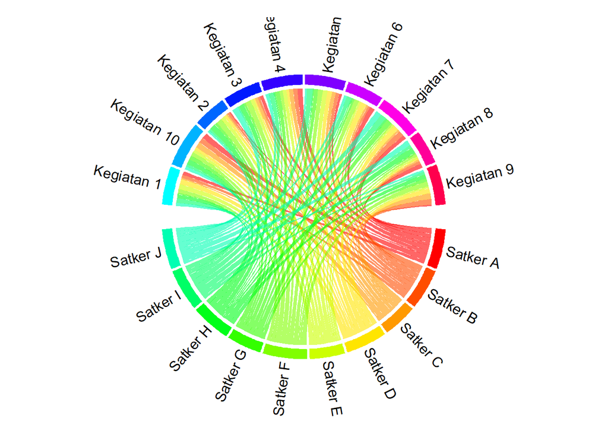

```r
# Menggabungkan data untuk membentuk matriks relasi antara Satker dan Kegiatan
matriks_chord <- xtabs(target ~ nama_satker + nama_kegiatan, data = data_keuangan)

# Menghitung jumlah sektor
sectors <- rownames(matriks_chord)
sectors <- unique(c(rownames(matriks_chord), colnames(matriks_chord)))

# Menetapkan warna dengan nama sektor
sector_colors <- setNames(rainbow(length(sectors)), sectors)

# Membuat Chord Diagram dengan warna khusus
chordDiagram(matriks_chord, transparency = 0.4, grid.col = sector_colors, annotationTrack = "grid", preAllocateTracks = 1)

# Menambahkan label pada sektor
circos.trackPlotRegion(track.index = 1, panel.fun = function(x, y) {
  sector.name = get.cell.meta.data("sector.index")
  circos.text(CELL_META$xcenter, CELL_META$ylim[1], sector.name, facing = "clockwise", niceFacing = TRUE, adj = c(0, 0.5))
}, bg.border = NA)
```

### 13. Menyimpan Plots: Menyimpan Hasil Visualisasi

Untuk menyimpan hasil visualisasi ke file, kita bisa menggunakan `ggsave()`. Kita bisa menentukan ukuran output dengan parameter `width` dan `height`.

```r
ggsave("palet_plot.png", palet_plot, width = 10, height = 15)
```